# Assessing the Impact of NPIs on Consumer Mobility Patterns and COVID-19 Transmission in the US

Joseph Zuccarelli, Laura Seaman, Kevin Rader

2023-08-30

In the following markdown document, we carry out all COVID-19 modeling using linear mixed effects models.

## COVID-19 Modeling

First, we must read in our two datasets.

```r
# Read in data sets
MA_data <- read.csv("/Users/jqz0816/Documents/MDPI/Data/MA_data.csv")
MI_data <- read.csv("/Users/jqz0816/Documents/MDPI/Data/MI_data.csv")

# Format date/indicator features properly
MI_data$date <- as.Date(MI_data$date)
MA_data$date <- as.Date(MA_data$date)
MI_data$date_factor <- as.factor(MI_data$date)
MA_data$date_factor <- as.factor(MA_data$date)
MA_data$work_closing <- as.factor(MA_data$work_closing)
MA_data$gather_restrict <- as.factor(MA_data$gather_restrict)
MA_data$stay_home_reqs <- as.factor(MA_data$stay_home_reqs)
MI_data$work_closing <- as.factor(MI_data$work_closing)
MI_data$gather_restrict <- as.factor(MI_data$gather_restrict)
MI_data$stay_home_reqs <- as.factor(MI_data$stay_home_reqs)

# Group data by date
MA_data_sample <- MA_data %>%
  group_by(date) %>%
  summarise(num_transactions_tot = sum(num_transactions),
            num_businesses_tot = sum(num_unique_businesses),
            num_zips_tot = sum(num_unique_zips),
            num_morning_tot = sum(num_morning),
            num_afternoon_tot = sum(num_afternoon),
            num_evening_tot = sum(num_evening),
            num_night_tot = sum(num_night),
            num_grocery_tot = sum(num_grocery),
            num_convenience_tot = sum(num_convenience),
            num_health_tot = sum(num_health),
            num_hotel_tot = sum(num_hotels),
            num_restaurant_tot = sum(num_restaurants))
MI_data_sample <- MI_data %>%
  group_by(date) %>%
  summarise(num_transactions_tot = sum(num_transactions),
            num_businesses_tot = sum(num_unique_businesses),
            num_zips_tot = sum(num_unique_zips),
            num_morning_tot = sum(num_morning),
            num_afternoon_tot = sum(num_afternoon),
            num_evening_tot = sum(num_evening),
            num_night_tot = sum(num_night),
            num_grocery_tot = sum(num_grocery),
            num_convenience_tot = sum(num_convenience),
            num_health_tot = sum(num_health),
            num_hotel_tot = sum(num_hotels),
            num_restaurant_tot = sum(num_restaurants))

# Mutate additional sample-level features
MA_data_idv <- MA_data %>%
  filter(uuid=="0007561724B170454D13B2F6CE227C3D77F116951F5A75BC258349DD18AD0733") %>%
  select(day,weekend,emergency,work_closing,gather_restrict,stay_home_reqs,
         case_count,case_rate,test_count,test_rate,date_factor)
MI_data_idv <- MI_data %>%
  filter(uuid=="000919F1AAA2A62098038034B268628BCAE1157EBC627042B45BFD7AF38A22C6") %>%
  select(day,weekend,emergency,work_closing,gather_restrict,stay_home_reqs,
         case_count,case_rate,test_count,test_rate,date_factor)
MA_data_sample <- cbind(MA_data_sample,MA_data_idv)
MI_data_sample <- cbind(MI_data_sample,MI_data_idv)
MA_data_sample$state <- as.factor('Boston, MA')
MI_data_sample$state <- as.factor('Ann Arbor, MI')
```

Now, let’s mutate the primary two features required for modeling: COVID-19 case growth rates and lagged delta transactions.

```r
# Create exp growth rate features
MA_data_sample <- MA_data_sample %>%
  mutate(case_growth_rate = 100*(log(case_count+1) - log(lag(case_count+1))))
MI_data_sample <- MI_data_sample %>%
  mutate(case_growth_rate = 100*(log(case_count+1) - log(lag(case_count+1))))

# Calculate pre-pandemic baseline transaction counts
MA_baseline <- MA_data_sample %>%
  filter(date < "2020-03-01") %>%
  group_by(day) %>%
  summarise(baseline_transactions = median(num_transactions_tot))
MI_baseline <- MI_data_sample %>%
  filter(date < "2020-03-01") %>%
  group_by(day) %>%
  summarise(baseline_transactions = median(num_transactions_tot))

# Merge baseline transaction feature
MA_data_sample <- merge(MA_data_sample,MA_baseline,by='day') %>%
  arrange(date) %>%
  mutate(delta_transactions = 100*((num_transactions_tot-baseline_transactions)/baseline_transactions))
MI_data_sample <- merge(MI_data_sample,MI_baseline,by='day') %>%
  arrange(date) %>%
  mutate(delta_transactions = 100*((num_transactions_tot-baseline_transactions)/baseline_transactions))
data_sample_plot <- rbind(MI_data_sample,MA_data_sample)
data_sample_plot$state <- factor(data_sample_plot$state, levels = c('Boston, MA',
                                                          'Ann Arbor, MI'))

# Mutate lagged transaction features
MA_data_emergency <- MA_data_sample %>%
  mutate(delta_trans_lag18 = lag(delta_transactions, n = 18),
         delta_trans_lag16 = lag(delta_transactions, n = 16),
         delta_trans_lag14 = lag(delta_transactions, n = 14),
         delta_trans_lag12 = lag(delta_transactions, n = 12),
         delta_trans_lag10 = lag(delta_transactions, n = 10),
         delta_trans_lag8 = lag(delta_transactions, n = 8),
         delta_trans_lag6 = lag(delta_transactions, n = 6)) %>%
  filter(emergency==1)
MI_data_emergency <- MI_data_sample %>%
  mutate(delta_trans_lag18 = lag(delta_transactions, n = 18),
         delta_trans_lag16 = lag(delta_transactions, n = 16),
         delta_trans_lag14 = lag(delta_transactions, n = 14),
         delta_trans_lag12 = lag(delta_transactions, n = 12),
         delta_trans_lag10 = lag(delta_transactions, n = 10),
         delta_trans_lag8 = lag(delta_transactions, n = 8),
         delta_trans_lag6 = lag(delta_transactions, n = 6)) %>%
  filter(emergency==1)

# Combine state DFs
data_emergency <- rbind(MA_data_emergency,MI_data_emergency)
```

Prior to performing any modeling, it is necessary to visualize the distributions of our response variables.

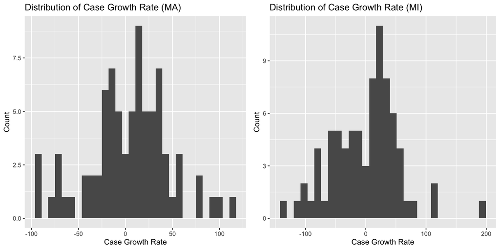

```r
# Histogram: Distribution of Case Growth Rate (MA)
MA_plot <- MA_data_emergency %>%
  ggplot(aes(x=case_growth_rate)) +
  geom_histogram()+
  labs(x="Case Growth Rate",y="Count",title="Distribution of Case Growth Rate (MA)")

# Histogram: Distribution of Case Growth Rate (MA)
MI_plot <- MI_data_emergency %>%
  ggplot(aes(x=case_growth_rate)) +
  geom_histogram()+
  labs(x="Case Growth Rate",y="Count",title="Distribution of Case Growth Rate (MI)")

# Subplots
plot_grid(MA_plot,MI_plot)
```

Note that for both samples the response variable appears to be normally distributed, suggesting that linear models are appropriate.